# Aula LM

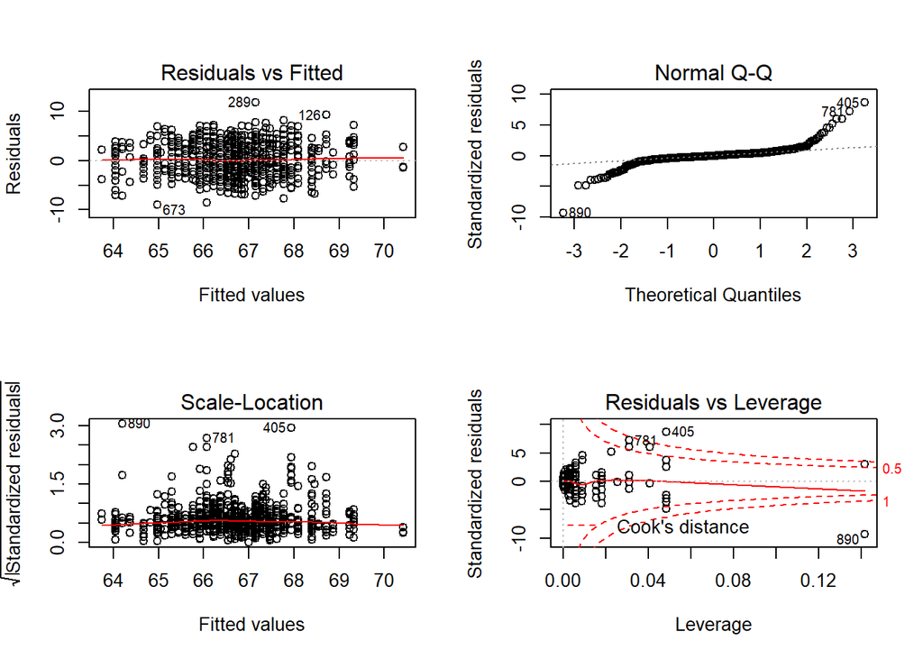

```r
par(mfrow=c(2,2))
plot(mod1)
```

Graficos

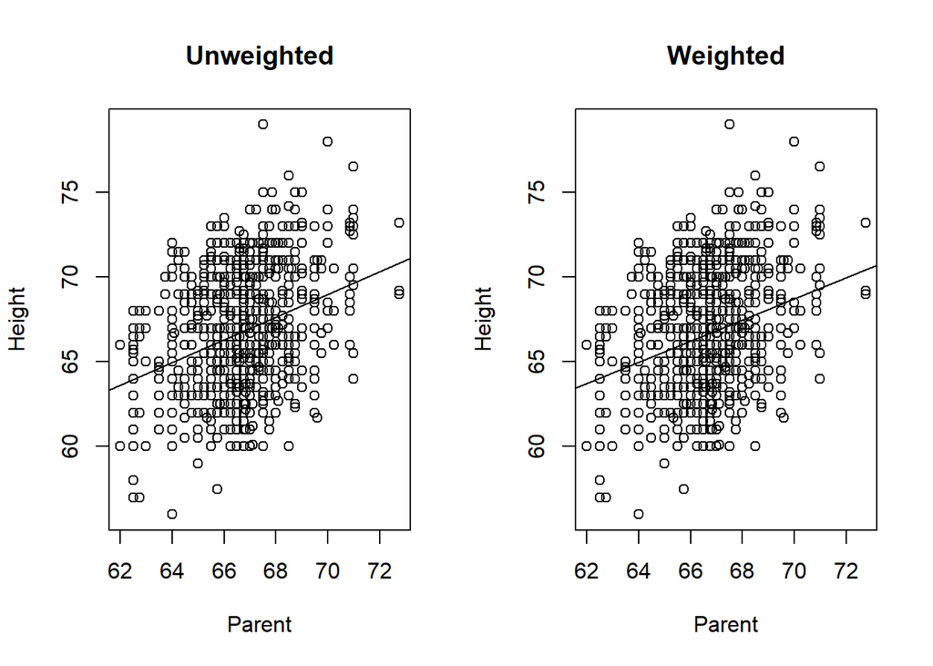

```r
par(mfrow=c(1,2))
plot(Height~Parent, galton, main="Unweighted"); abline(a = coef(mod0)[1], b = coef(mod0)[2])
plot(Height~Parent, galton, main="Weighted"); abline(a = coef(mod1)[1],   b = coef(mod1)[2])
```

Pela definição, $\sigma^2/w_i = var[y_i] = E[(y_i-\hat{y}_i)^2]$, e considerando que $RSS = w_i(y_i-\hat{y}_i)^2$. Porém, como o valor de $\hat{y}$ é estimado, estimamos a variância como $s^2$, sendo então:
$$s^2 = \frac{RSS}{n-2}$$

```r
df <- length(y) - 2
s2 <- RSS / df
c( df = df, s=sqrt(s2), s2=s2 )
```

```
##         df          s         s2
## 896.000000   2.303943   5.308155
```

Já o Erro padrão dos coeficientes é calculado conforme:

$$\text{var}[\hat{\beta_1}] = \frac{\sigma^2}{SS_x}$$

Podemos estabelecer que:

$$\text{se}(\hat{\beta_0}) = s\sqrt{\frac{1}{\sum{w_i}}+\frac{\bar{x_w}^2 }{SS_x} }$$
e

$$\text{se}(\hat{\beta_1}) = \frac{s}{\sqrt{SS_x}}$$

```r
var_beta0 <- s2 * ( 1/sum(wts) + x_medio^2 / SSx )
var_beta1 <- s2 / SSx
sqrt( c( beta0=var_beta0, beta1=var_beta1) ) # The std errors
```

```
##      beta0      beta1
## 4.58620591 0.06858485
```

Para estimativa de $\hat{y}$ e erro padrão associado, estabelecemos que:
$$\text{var}[\hat{y}_{novo}] = \sigma^2\{\frac{1}{\sum{w_i}}+\frac{(x_{novo}-\bar{x})^2}{SS_x} \}$$

Logo, um casal de pais altos (80)

```r
x_novo <- 80
y_chapeu_novo <- beta0 + beta1*x_novo
var_y_chapeu_novo <- s2 * ( 1/sum(wts) + (x_novo - x_medio)^2 / SSx )
se_y_chapeu_novo <- sqrt(var_y_chapeu_novo)
c( y_hat = y_chapeu_novo, se = sqrt(var_y_chapeu_novo))
```

```
##      y_hat         se
## 74.9249856  0.9104857
```

```r
predict.lm(mod1, data.frame(Parent=x_novo), se=T)
```

```
## $fit
##        1
## 74.92499
##
## $se.fit
## [1] 0.9315158
##
## $df
## [1] 856
##
## $residual.scale
## [1] 2.357159
```

Determinar a correta ponderação é difícil. Normalmente, observações com variações pequenas devem ter pesos relativamente grandes e observações com variações grandes devem ter pesos relativamente pequenos.

Suponha que seu modelo de regressão preveja o número anual de acidentes de trânsito em diferentes cidades. Como cidades mais populosas tendem a sofrer mais acidentes, os resíduos de cidades maiores também tendem a ser maiores. Uma abordagem para resolver isso é usar o recíproco da população de cada cidade para o peso.

A especificação de uma variável como peso (`weights`) afeta as somas dos quadrados e as estimativas de parâmetros das seguintes maneiras: * As somas de quadrados tornam-se somas ponderadas de quadrados. * Uma média ponderada é usada na soma total de quadrados. * Um critério de mínimos quadrados ponderados é usado para estimar os parâmetros.

### Exercício 6 - crawl

Um estudo de bebês levantou a hipótese de que os bebês demorariam mais para aprender a engatinhar nos meses mais frios, porque as roupas extras restringem seus movimentos. De 1988 a 1991, foram registradas a primeira idade de rastreamento dos bebês e a temperatura média mensal seis meses após o nascimento (quando “os bebês presumivelmente entram na janela de prontidão locomotora”). Os pais relataram o mês do nascimento e a idade em que o bebê rastejou ou rastejou uma distância de quatro pés em um minuto. Os dados foram coletados no Centro de Estudos Infantis da Universidade de Denver em 208 meninos e 206 meninas e resumidos pelo mês do nascimento (Tabela a seguir; conjunto de dados: `crawl`, pacote `GLMsData`).

```r
data("crawl")
crawl %>%
  kable() %>%
  kable_styling(bootstrap_options = c("striped", "hover", "condensed", "responsive"))
```

| BirthMonth | Age | SD | SampleSize | Temp |
| --- | --- | --- | --- | --- |
| January | 29.84 | 7.08 | 32 | 66 |
| February | 30.52 | 6.96 | 36 | 73 |
| March | 29.70 | 8.33 | 23 | 72 |
| April | 31.84 | 6.21 | 26 | 63 |
| May | 28.58 | 8.07 | 27 | 52 |
| June | 31.44 | 8.10 | 29 | 39 |
| July | 33.64 | 6.91 | 21 | 33 |
| August | 32.82 | 7.61 | 45 | 30 |
| September | 33.83 | 6.93 | 38 | 33 |
| October | 33.35 | 7.29 | 44 | 37 |
| November | 33.38 | 7.42 | 49 | 48 |
| December | 32.32 | 5.71 | 44 | 57 |

#### a) Análise Exploratório dos Dados

Plote os dados. Quais pressupostos, se houver, parecem violadas?

#### b) WLS

Explique por que um modelo de regressão ponderado é apropriado para os dados.

#### c) LM

Ajuste um modelo de regressão linear ponderada aos dados e interprete os coeficientes de regressão.

#### d) Conclua

Teste formalmente a hipótese proposta pelos pesquisadores.

#### e) IC 90%

Encontre um intervalo de confiança de 90% para a inclinação da linha ajustada e interprete

Fonte: [Dunn & Smyth, 2018](https://www.springer.com/gp/book/9781441901170)